# Quantifying Effective Barbell Use

Stephen Franklin

July 17, 2014

Excerpt from [Groupware@LES](http://groupware.les.inf.puc-rio.br/har):

Six young health participants were asked to perform one set of 10 repetitions of the Unilateral Dumbbell Biceps Curl in five different fashions: exactly according to the specification (Class A), throwing the elbows to the front (Class B), lifting the dumbbell only halfway (Class C), lowering the dumbbell only halfway (Class D) and throwing the hips to the front (Class E).

Class A corresponds to the specified execution of the exercise, while the other 4 classes correspond to common mistakes. Participants were supervised by an experienced weight lifter to make sure the execution complied to the manner they were supposed to simulate. The exercises were performed by six male participants aged between 20-28 years, with little weight lifting experience. We made sure that all participants could easily simulate the mistakes in a safe and controlled manner by using a relatively light dumbbell (1.25kg).

For data recording we used four 9 degrees of freedom Razor inertial measurement units (IMU), which provide three-axes acceleration, gyroscope and magnetometer data at a joint sampling rate of 45 Hz.

The four IMUs are located on the dumbell, forearm, upper arm, and the waist.

#### Preliminary Examination of Dataset:

There are six subjects and 19,622 observations. Each subject has many observations over a short period of time (0.5 - 2.0 seconds).

There are occasional observatons for which the ‘new_window’ variable is marked ‘yes’, and which have additional features. There are features for each dimension and location: kurtosis, skewness, max, min, amplitude, avg, stddev, var; as well as ‘var_total_accel_’ for each location.

We are provided the test set, ‘pml-testing.csv’, so we ought to ascertain some important things about it. (Although one doesn’t usually look at their test set, they do usually know some basic things about it.) Firstly, the test set is not time sliced, so we needn’t worry about deriving time sliced predictions. Second, the test set doesn’t contain any data for the additional features that accompany ‘new_window = yes’, therefore all of that data may be safely ignored. This test set is actually the grading test set and doesn’t contain the outcomes. (The last column is ‘problem_id’ instead of ‘classe’.) We’ll make a new test set from ‘pml-training.csv’ to evaluate our predictions.

## Analysis

### Get the data

The data used in this analysis was collected by [Groupware@LES](http://groupware.les.inf.puc-rio.br/har).

```r
data_train <- "https://d396qusza40orc.cloudfront.net/predmachlearn/pml-training.csv"
data_test <- "https://d396qusza40orc.cloudfront.net/predmachlearn/pml-testing.csv"
download.file(url = data_train, destfile = "pml-training.csv",method = "wget")
download.file(url = data_test, destfile = "pml-testing.csv",method = "wget")
```

### Load the data:

```r
pml.training <- read.csv("pml-training.csv")
pml.testing <- read.csv("pml-testing.csv")
#edit(pml.training)
#edit(pml.testing)

### Cull unnecessary variables ###
except.these <- grep("kurtosis|skewness|max|min|amplitude|avg|stddev|var", names(pml.training))
except.these <- c(except.these,c(1:7)) ## time and identification variables (X, user_name, cvtd_timestamp, raw_timestamp_part_2, new_window, num_window).
pml.training1 <- pml.training[,-except.these]
#View(pml.training1)
sum(is.na(pml.training1))  ## Check for NAs. 0 is nice.
```

```
## [1] 0
```

```r
pml.testing1 <- pml.testing[,-except.these]

### Integer variables to numeric ###
which( colnames(pml.training1)=="classe" )  ## <-- classe is the outcome.
```

```
## [1] 53
```

```r
pml.training1[, -53] <- as.data.frame(lapply(pml.training1[,-53],as.numeric))
pml.testing1[, -53] <- as.data.frame(lapply(pml.testing1[,-53],as.numeric))
#str(pml.training1)
```

### R Libraries

```r
library(caret); library(randomForest); library(rpart)
```

### Split Data

We’ll reserve 80% of our data for training and 20% for the test set.

```r
set.seed(42)
inTrain <- createDataPartition(y=pml.training1$classe,
                              p=0.80, list=FALSE)
training <- pml.training1[inTrain,]
testing <- pml.training1[-inTrain,]
training[1,53]
```

```
## [1] A
## Levels: A B C D E
```

```r
class(training$classe)
```

```
## [1] "factor"
```

```r
dim(training);dim(testing)
```

```
## [1] 15699    53
```

```
## [1] 3923   53
```

The training set is now randomized (though equally distributed amongst the five classes of our outcome variable ‘classe’.)

### Model with Trees

We’ll train a model the Classification and Regression Tree (CART) algorithm (`method='rpart'`). We’ll also use a 10-fold cross-validation (from within the `trControl` settings).

```r
set.seed(42)
system.time( barb.tr <- train(classe ~ .,method="rpart",data=training, trControl = trainControl(method = "cv", number = 10)) )
```

```
##    user  system elapsed
##  37.264   0.989  41.855
```

```r
####   user  system elapsed
#### 36.995   0.913  41.745
```

#### Trees Analysis

```r
barb.tr$finalModel
```

```
## n= 15699
##
## node), split, n, loss, yval, (yprob)
##       * denotes terminal node
##
##  1) root 15699 11240 A (0.28 0.19 0.17 0.16 0.18)
##    2) roll_belt< 130.5 14396  9943 A (0.31 0.21 0.19 0.18 0.11)
##      4) pitch_forearm< -33.15 1280    13 A (0.99 0.01 0 0 0) *
##      5) pitch_forearm>=-33.15 13116  9930 A (0.24 0.23 0.21 0.2 0.12)
##       10) magnet_dumbbell_y< 439.5 11095  7973 A (0.28 0.18 0.24 0.19 0.11)
##         20) roll_forearm< 123.5 6889  4104 A (0.4 0.18 0.18 0.17 0.061) *
##         21) roll_forearm>=123.5 4206  2819 C (0.08 0.17 0.33 0.23 0.19) *
##       11) magnet_dumbbell_y>=439.5 2021   992 B (0.032 0.51 0.045 0.22 0.2) *
##    3) roll_belt>=130.5 1303    11 E (0.0084 0 0 0 0.99) *
```

```r
barb.tr$resample ## error rate of each fold
```

```
##    Accuracy  Kappa Resample
## 1    0.5137 0.3660   Fold02
## 2    0.4984 0.3455   Fold01
## 3    0.4904 0.3345   Fold03
## 4    0.5226 0.3763   Fold06
## 5    0.5029 0.3498   Fold05
## 6    0.4997 0.3471   Fold04
## 7    0.4885 0.3317   Fold07
## 8    0.4904 0.3341   Fold10
## 9    0.5159 0.3673   Fold09
## 10   0.5210 0.3745   Fold08
```

```r
barb.tr$results ## cp = complexity parameter
```

```
##        cp Accuracy  Kappa AccuracySD KappaSD
## 1 0.03703   0.5044 0.3527    0.01303 0.01709
## 2 0.05978   0.4389 0.2475    0.06641 0.11154
## 3 0.11402   0.3310 0.0711    0.04033 0.06126
```

```r
confusionMatrix(barb.tr)
```

```
## Cross-Validated (10 fold) Confusion Matrix
##
## (entries are percentages of table totals)
##
##           Reference
## Prediction    A    B    C    D    E
##          A 25.7  8.2  8.0  7.4  2.6
##          B  0.5  6.5  0.6  2.8  2.6
##          C  1.8  3.4  8.2  4.4  3.6
##          D  0.3  1.2  0.7  1.8  1.3
##          E  0.1  0.0  0.0  0.0  8.2
```

```r
### Test the Tree Model ###
pred.te<- predict(barb.tr,newdata=testing)
testing$predtrRight <- pred.te==testing$classe
table(pred.te,testing$classe)
```

```
##
## pred.te    A    B    C    D    E
##       A 1033  312  326  289  107
##       B   17  257   18  128   88
##       C   63  190  340  226  187
##       D    0    0    0    0    0
##       E    3    0    0    0  339
```

```r
1-sum(testing$predtrRight)/nrow(testing)  ## out of sample error rate
```

```
## [1] 0.4981
```

### Model with Random Forest

#### This Random Forest took too long to calculate proximities with the 80% training set and with `prox=TRUE`.

```r
### Train with 80% ###
set.seed(42)
system.time( barb80.rf <- train(classe~ .,data=training,method="rf",prox=TRUE) )
#### With 80% of the data in the training set,
#### this command took . . . failed.
#### Timing stopped at: 33087.95 353.427 38917.49
```

#### This Random Forest model uses a training set of 20% to keep the processing time down (`prox = TRUE`).

##### Split the Data (20/80)

```r
set.seed(42)
inTrain <- createDataPartition(y=pml.training1$classe,
                              p=0.20, list=FALSE)
training20 <- pml.training1[inTrain,]
testing80 <- pml.training1[-inTrain,]
training20[1,53]
```

```
## [1] A
## Levels: A B C D E
```

```r
class(training20$classe)
```

```
## [1] "factor"
```

```r
dim(training20);dim(testing80)
```

```
## [1] 3927   53
```

```
## [1] 15695    53
```

##### Train the Random Forest model (20%)

```r
set.seed(42)
system.time( barb.rf <- train(classe ~., data=training20,method="rf",prox=TRUE) )
```

```
##    user  system elapsed
## 3450.31   37.99 3611.49
```

```r
####     user   system  elapsed
#### 3395.666   34.611 3509.028
```

```r
barb.rf$finalModel
```

```
##
## Call:
##  randomForest(x = x, y = y, mtry = param$mtry, proximity = TRUE)
##                Type of random forest: classification
##                      Number of trees: 500
## No. of variables tried at each split: 27
##
##         OOB estimate of  error rate: 2.39%
## Confusion matrix:
##      A   B   C   D   E class.error
## A 1108   4   3   0   1    0.007168
## B   15 727  16   1   1    0.043421
## C    0  13 662  10   0    0.033577
## D    0   0  17 626   1    0.027950
## E    0   4   2   6 710    0.016620
```

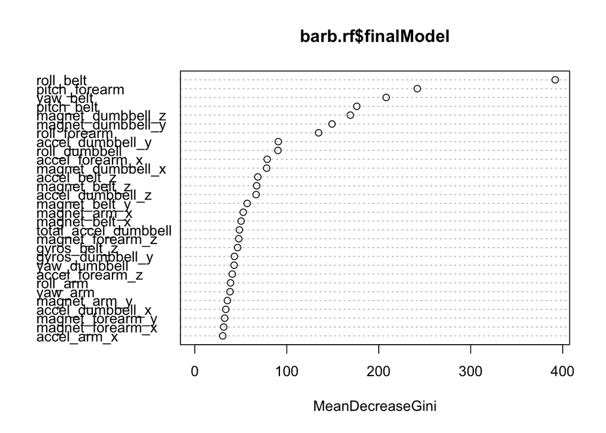

```r
varImpPlot(barb.rf$finalModel)
```

```r
### Get features in order of importance ###
imp <- as.data.frame(barb.rf$finalModel$importance)
imp <- cbind(feature = rownames(imp), imp)
rownames(imp)<-NULL
head(imp[with(imp, order(-MeanDecreaseGini)), ],10)
```

```
##              feature MeanDecreaseGini
## 1          roll_belt           391.90
## 41     pitch_forearm           241.92
## 3           yaw_belt           208.08
## 2         pitch_belt           176.09
## 39 magnet_dumbbell_z           169.11
## 38 magnet_dumbbell_y           149.21
## 40      roll_forearm           134.60
## 35  accel_dumbbell_y            90.79
## 27     roll_dumbbell            90.33
## 47   accel_forearm_x            78.69
```

The out-of-bag error rate is 2.39%.

#### Predicting the random forest model with the test set of 80%

```r
pred <- predict(barb.rf,testing80)
testing80$predRight <- pred==testing80$classe
table(pred,testing80$classe)
```

```
##
## pred    A    B    C    D    E
##    A 4402   57    0    0    0
##    B   51 2938   74    7   16
##    C    8   35 2635   53   14
##    D    2    7   28 2510   33
##    E    1    0    0    2 2822
```

```r
### Out-of-Sample error rate ###
1-sum(testing80$predRight)/nrow(testing80)
```

```
## [1] 0.02472
```

#### This Random Forest model uses an 80% Training set but doesn’t calculate proximities (`prox=FALSE`).

```r
set.seed(42)
system.time( barb80.rf <- train(classe~ .,data=training,method="rf",prox=FALSE) )
```

```
##    user  system elapsed
## 8491.09   75.26 8858.41
```

```r
####     user   system  elapsed
#### 8358.456   66.568 8647.038
```

```r
### Get features in order of importance ###
imp80 <- as.data.frame(barb80.rf$finalModel$importance)
imp80 <- cbind(feature = rownames(imp80), imp80)
rownames(imp80)<-NULL
head(imp80[with(imp80, order(-MeanDecreaseGini)), ],10)
```

```
##              feature MeanDecreaseGini
## 1          roll_belt            538.1
## 3           yaw_belt            491.4
## 39 magnet_dumbbell_z            432.2
## 2         pitch_belt            413.9
## 41     pitch_forearm            390.5
## 38 magnet_dumbbell_y            385.3
## 37 magnet_dumbbell_x            346.4
## 40      roll_forearm            338.3
## 10      accel_belt_z            325.4
## 27     roll_dumbbell            317.0
```

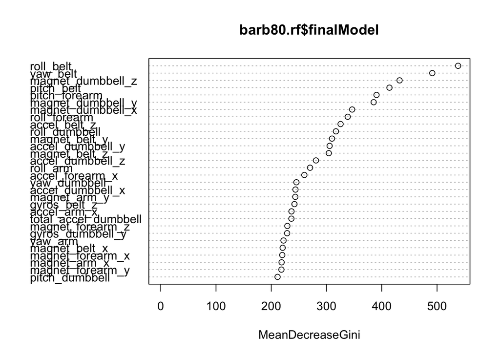

```r
varImpPlot(barb80.rf$finalModel)
```

```r
barb80.rf$finalModel
```

```
##
## Call:
##  randomForest(x = x, y = y, mtry = param$mtry, proximity = FALSE)
##                Type of random forest: classification
##                      Number of trees: 500
## No. of variables tried at each split: 2
##
##         OOB estimate of  error rate: 0.5%
## Confusion matrix:
##      A    B    C    D    E class.error
## A 4462    2    0    0    0    0.000448
## B    9 3025    4    0    0    0.004279
## C    0   16 2719    3    0    0.006939
## D    0    0   38 2534    1    0.015157
## E    0    0    1    4 2881    0.001733
```

#### PREDICTION with the test set (20%)

The features’ importance branches differently than the previous model. It attains an out-of-bag error rate of 0.5% and an out-of-sample error rate of 0.6%.

```r
pred <- predict(barb80.rf,testing)
testing$predRight <- pred==testing$classe
table(pred,testing$classe)
```

```
##
## pred    A    B    C    D    E
##    A 1116    3    0    0    0
##    B    0  754    1    0    1
##    C    0    2  681   14    0
##    D    0    0    2  628    0
##    E    0    0    0    1  720
```

```r
table(testing$predRight,testing$classe)
```

```
##
##            A    B    C    D    E
##   FALSE    0    5    3   15    1
##   TRUE  1116  754  681  628  720
```

```r
### Out-of-Sample Error rate ###
1-sum(testing$predRight)/nrow(testing)
```

```
## [1] 0.006118
```

#### Out-of-bag Error Estimate without Cross Validation

In random forests, there is no need for cross-validation or a separate test set to get an unbiased estimate of the test set error. Instead we use the out-of-bag error estimate. http://www.stat.berkeley.edu/~breiman/RandomForests/cc_home.htm#ooberr

## Works Cited

Ugulino, W.; Cardador, D.; Vega, K.; Velloso, E.; Milidiu, R.; Fuks, H. Wearable Computing: Accelerometers’ Data Classification of Body Postures and Movements. Proceedings of 21st Brazilian Symposium on Artificial Intelligence. Advances in Artificial Intelligence - SBIA 2012. In: Lecture Notes in Computer Science. , pp. 52-61. Curitiba, PR: Springer Berlin / Heidelberg, 2012. ISBN 978-3-642-34458-9. DOI: 10.1007/978-3-642-34459-6_6. Cited by 2 (Google Scholar)